# HW 1 - IE 6600 – Sec 1 - Valli Meenaa Vellaiyan

Valli Meenaa Vellaiyan || NUID: 002783394

2023-01-17

# Problem statement

1. To understand basic R commands (for creating vectors, matrices, etc.) and performing basic analysis on one of the in-built datasets in R-Studio.
2. To create an R-Markdown file and knit it to a pdf/html file.

## Task 1

```
## [1] "/Users/vallimeenaa/Desktop/Grad/SEM 2/IE 6600 Computation and Visualization for Analytics"
```

### Output 1

The function “getwd()” is used to display the filepath of the current working directory.

## Task 2

```
## [1] "numeric"
```

```
## [1] "character"
```

### Output 2

Variable x is assigned with a numeric value of 1, therefore class(x) returns “numeric”. Variable y is assigned with the character “1”, therefore class(y) returns “character”.

## Task 3

```
## [1] 7 2 1 6 5
```

```
## [1] 5
```

```
## [1] 1
```

```
## [1] 1
```

```
## [1] 1
```

### Output 3

A numeric vector “vect” of length 5 is created, consisting of the elements 7, 2, 1, 6, 5. The third element of this vector is accessed in three different ways, by using vector indexing.

## Task 4

```
##      [,1] [,2]
## [1,]    1    3
## [2,]    2    4
```

```
##      [,1] [,2] [,3]
## [1,]    1    3    5
## [2,]    2    4    6
```

```
##      [,1] [,2] [,3]
## [1,]    1    3    5
## [2,]    2    4    6
## [3,]    8    9   10
```

## Task 5

```
##   Sepal.Length Sepal.Width Petal.Length Petal.Width Species
## 1          5.1         3.5          1.4         0.2  setosa
## 2          4.9         3.0          1.4         0.2  setosa
## 3          4.7         3.2          1.3         0.2  setosa
## 4          4.6         3.1          1.5         0.2  setosa
## 5          5.0         3.6          1.4         0.2  setosa
```

```
##    speed dist
## 46    24   70
## 47    24   92
## 48    24   93
## 49    24  120
## 50    25   85
```

### Output 5

The “head()” function is used to display the first 5 rows of the “iris” dataframe. The “tail()” function is used to display the last 5 rows of the “cars” dataframe.

## Task 6

```
##    Ozone Solar.R Wind Temp Month Day
## 1     41     190  7.4   67     5   1
## 2     36     118  8.0   72     5   2
## 3     12     149 12.6   74     5   3
## 4     18     313 11.5   62     5   4
## 5     NA      NA 14.3   56     5   5
## 6     28      NA 14.9   66     5   6
## 7     23     299  8.6   65     5   7
## 8     19      99 13.8   59     5   8
## 9      8      19 20.1   61     5   9
## 10    NA     194  8.6   69     5  10
```

```
##      Ozone           Solar.R           Wind             Temp
##  Min.   :  1.00   Min.   :  7.0   Min.   : 1.700   Min.   :56.00
##  1st Qu.: 18.00   1st Qu.:115.8   1st Qu.: 7.400   1st Qu.:72.00
##  Median : 31.50   Median :205.0   Median : 9.700   Median :79.00
##  Mean   : 42.13   Mean   :185.9   Mean   : 9.958   Mean   :77.88
##  3rd Qu.: 63.25   3rd Qu.:258.8   3rd Qu.:11.500   3rd Qu.:85.00
##  Max.   :168.00   Max.   :334.0   Max.   :20.700   Max.   :97.00
##  NA's   :37       NA's   :7
##      Month            Day
##  Min.   :5.000   Min.   : 1.0
##  1st Qu.:6.000   1st Qu.: 8.0
##  Median :7.000   Median :16.0
##  Mean   :6.993   Mean   :15.8
##  3rd Qu.:8.000   3rd Qu.:23.0
##  Max.   :9.000   Max.   :31.0
##
```

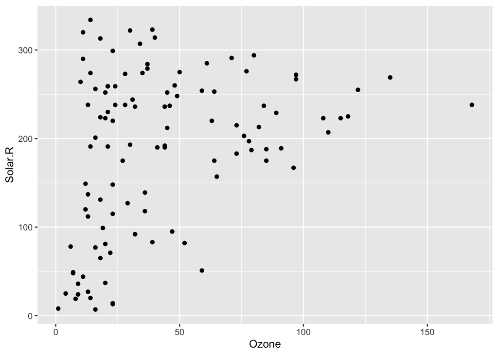

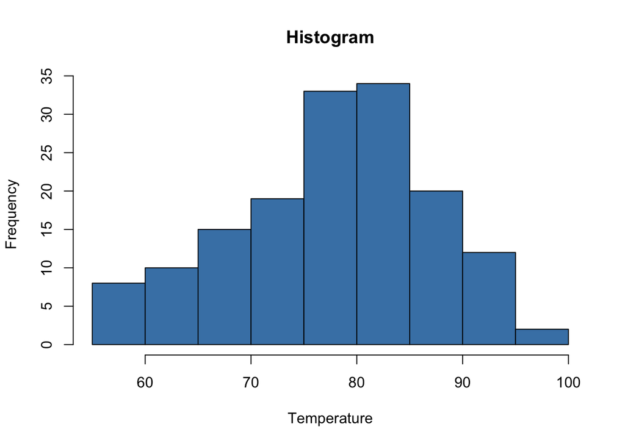

```
##         Ozone Solar.R       Wind       Temp        Month          Day
## Ozone       1      NA         NA         NA           NA           NA
## Solar.R    NA       1         NA         NA           NA           NA
## Wind       NA      NA  1.0000000 -0.4579879 -0.178292579  0.027180903
## Temp       NA      NA -0.4579879  1.0000000  0.420947252 -0.130593175
## Month      NA      NA -0.1782926  0.4209473  1.000000000 -0.007961763
## Day        NA      NA  0.0271809 -0.1305932 -0.007961763  1.000000000
```

```
## Correlation between wind and ozone is NA
```

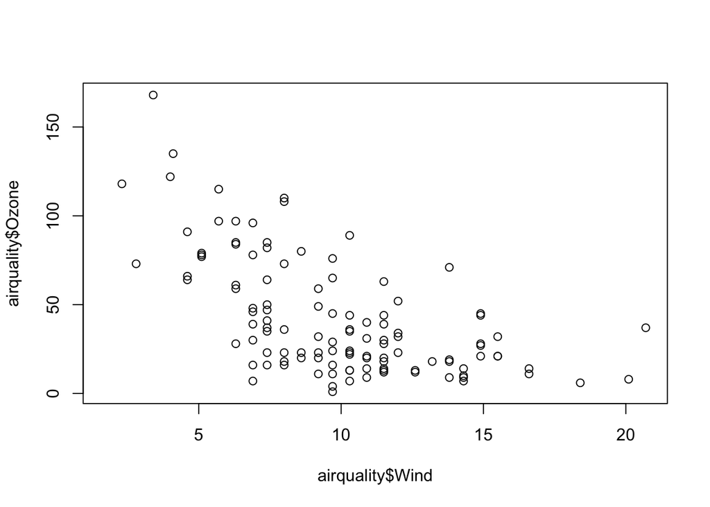

```
## Correlation between temperature and ozone is NA
```

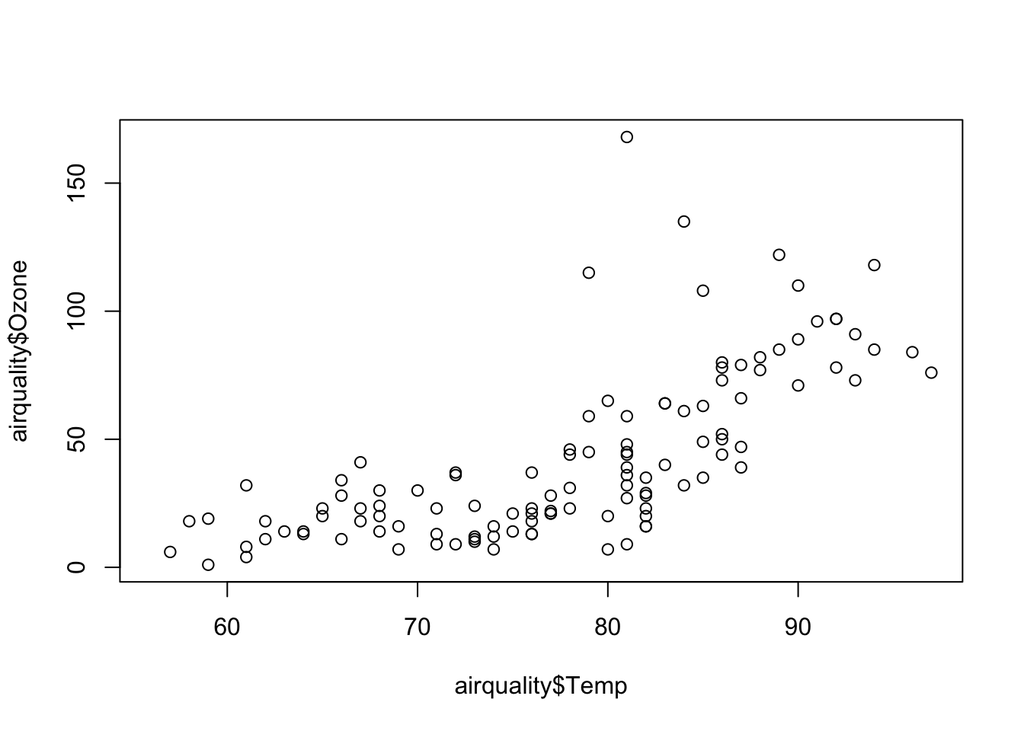

```
## K-means clustering with 4 clusters of sizes 27, 41, 23, 20
##
## Cluster means:
##      Ozone   Solar.R     Wind     Temp
## 1 19.85185  50.40741 11.43704 71.29630
## 2 33.82927 268.46341 10.88049 76.14634
## 3 94.30435 217.13043  6.46087 88.95652
## 4 29.05000 157.55000  9.99000 77.10000
##
## Clustering vector:
##   1   2   3   4   7   8   9  12  13  14  15  16  17  18  19  20  21  22  23  24
##   4   4   4   2   2   1   1   2   2   2   1   2   2   1   2   1   1   2   1   1
##  28  29  30  31  38  40  41  44  47  48  49  50  51  62  63  64  66  67  68  69
##   1   2   3   2   4   2   2   4   4   2   1   4   4   3   2   2   4   2   2   3
##  70  71  73  74  76  77  78  79  80  81  82  85  86  87  88  89  90  91  92  93
##   3   3   2   4   1   2   2   2   3   3   1   2   3   1   1   3   2   2   2   1
##  94  95  99 100 101 104 105 106 108 109 110 111 112 113 114 116 117 118 120 121
##   1   1   3   3   3   4   2   4   1   1   4   2   4   2   1   3   3   3   3   3
## 122 123 124 125 126 127 128 129 130 131 132 133 134 135 136 137 138 139 140 141
##   3   3   3   3   3   3   1   1   2   2   2   2   2   2   2   1   4   2   2   1
## 142 143 144 145 146 147 148 149 151 152 153
##   2   4   2   1   4   1   1   4   4   4   2
##
## Within cluster sum of squares by cluster:
## [1] 32849.30 54609.41 35100.73 24296.46
##  (between_SS / total_SS =  86.0 %)
##
## Available components:
##
## [1] "cluster"      "centers"      "totss"        "withinss"     "tot.withinss"
## [6] "betweenss"    "size"         "iter"         "ifault"
```

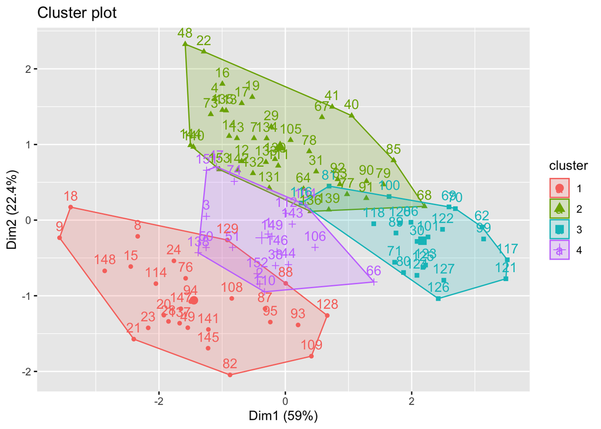

### Output 6

The “data()” function is used to get a list of all the in-built datasets present in R. I chose the dataset “airquality”, which consist of the daily readings of 4 air quality values (Ozone, Solar, Wind, Temp) in New York, from May to September 1973. The “head()” function returns the first 10 rows of the dataset. To learn more about the attributes and definitions of the selected datatset, I’ve used the “help()” function.

# Conclusion

1. I learnt to use the “getwd()” function to get my current working directory. I used the “class()” function to find the class of a variable.
2. I learnt to create a vector and perform a few operations on the vector, like finding the length, retrieving an element from it, etc. I also learnt to create a matrix and combine matrices using “rbind()” and “cbind()” functions.
3. Further, I learnt to work with in-built datasets in R-Studio. I performed different types of analyses on the “airquality” dataset. I summarized the dataset which produced the mean, median, min, max, and quartile values of each column in the dataset. I worked with scatterplots and histograms to observe the distribution of data points and explore relationships between different variables of the dataset.
4. Using the abovementioned dataset, I also worked with the “cor()” function to find the correlation between different variables. Moreover, I learnt to create a kmeans model to perform clustering of data, and then plotted the clusters using “fviz_cluster()” function.